# A Homework on Maps in R

### Data needed:

- Shapefile of Philadelphia census tracts and homicide rates: [Philly3.zip](https://www.dropbox.com/s/pw4611p7x3h5sqa/Philly3.zip?dl=1) . Inside of the zip file is a directory called `Philly3`.

**Make sure that you place an unzipped copy of that directory as a subdirectory in your working directory.**

```r
## need this file for later
philly <- readOGR("Philly3", "Philly3", verbose = F)
names(philly)
```

```
##  [1] "OBJECTID"  "AREA"      "PERIMETER" "TRACTID"   "FIPSSTCO"  "TRT2000"
##  [7] "STFID"     "N_HOMIC"   "TOTALPO"   "mdHHnc_"   "HOMIC_R"   "PCT_COL"
```

Use `names()` to see the attributes that Claudia has added to supplement the existing geospatial fields:

- *N_HOMIC*: Number of homicides (since 2006)
- *HOMIC_R*: homicide rate per 100,000 (Philadelphia Open Data)
- *PCT_COL*: % 25 years and older with college or higher degree[^1] (ACS 2006-2010)
- *mdHHnc*: estimated median household income (ACS 2006-2010)

##### **(Q1)** What package is the `readOGR()` function from.

Inside Rstudio, drill down a little bit into `philly` so that you can appreciate the complexities of a spatial data. In this instance, the geospatial objects are polygons - and defining the polygons is the majority of the data. Additionally, this spatial dataframe includes data about each of the polygons.

> *rgdal* is an older package that focus on input and output - getting spatial data into R (from other standard sources) and producing files that could be read by other spatial software.

## 2. Choropleth mapping with `spplot`

The *sp* package provides a standarized set of objects and methods for spatial analysis. Many packages use the sp objects.

Base R has the ability to plot these objects.

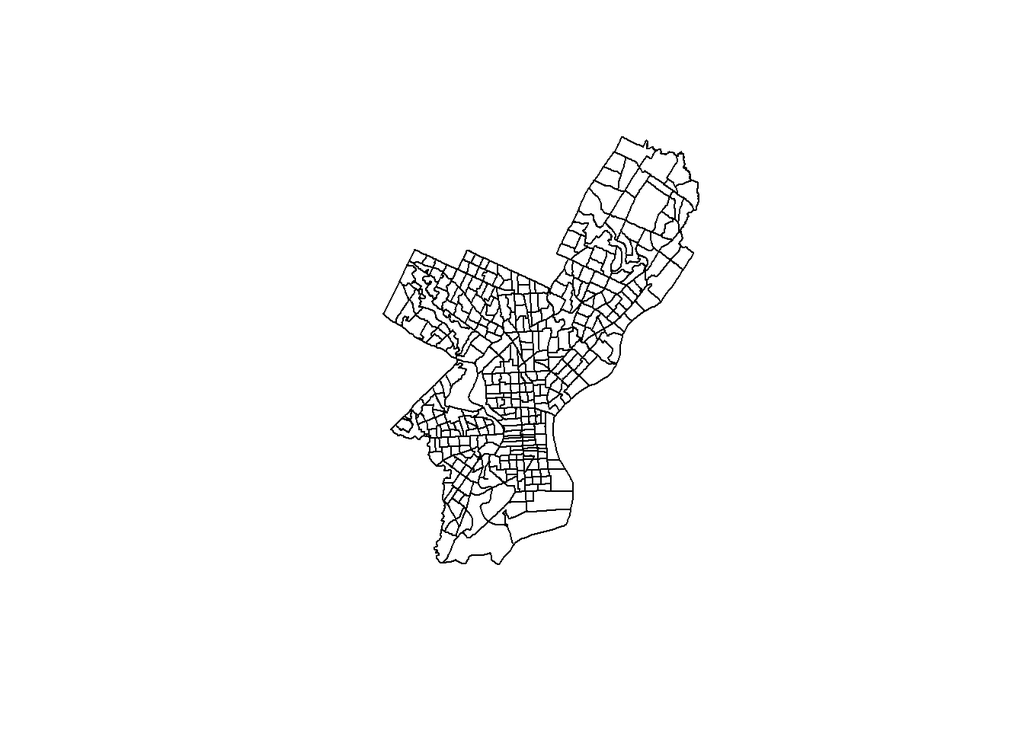

```r
plot (philly)
```

`sp` comes with a plot command `spplot()`, which takes `Spatial*` objects to plot. `spplot()` is one of the earliest functions to plot geographic objects.

The `ssplot` command also allows for visualization, but you will (typically) want to select a data attribute to be plotted.

##### **(a)** Use the `spplot` command (make sure you installed and loaded `sp`) to make a chloropleth using Homicide Rate data.

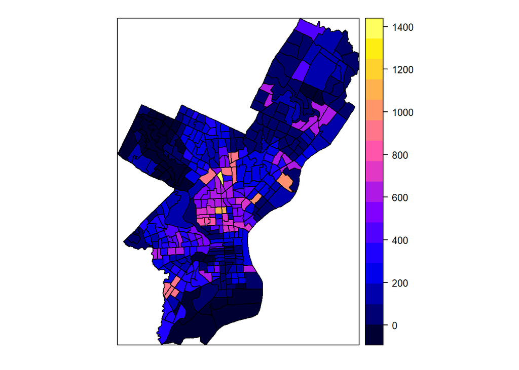

```r
spplot(philly, 'HOMIC_R')
```

Based on what we have learned in this course, we might suspect that we can improve on the default coloring scheme. Taking advantage the *viridis* color scale, and a continuous coloring scheme.

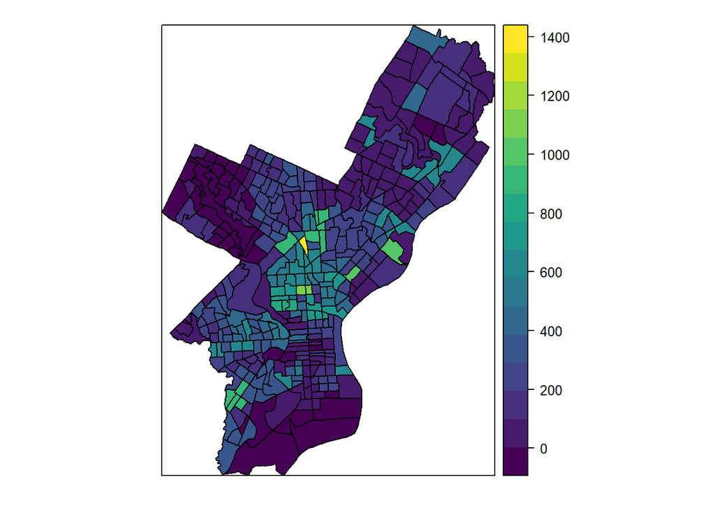

```r
spplot(philly,"HOMIC_R", col.regions = viridis(256))
```

We know the color scale has nice properties, but we still have this one area standing out with an extremely high homicide rate, which makes a large part of the map unreadable. So let’s change the class intervals to quantiles. We will use `classIntervals` from the `classInt` library, something like:

```
    breaks_qt <- classIntervals(vector_of_values,
                                n = how_many_classes,
                                style = "quantile" [can be omitted -- the default])

This returns an object of type `classIntervals`. Find out its structure. How would you access the break values?
```

```r
breaks_qt <- classIntervals(philly$HOMIC_R, n = 5,dataPrecision=2)
head(breaks_qt)
```

[output not shown]

[output cut: 53 more lines]

R is not always perfect. We need to “dress up” this result a little bit, otherwise it will (sometimes) cut off part of the range of interest, which would leave some polygons without a color assigned.

```r
br <- breaks_qt$brks
offs <- 0.0000001
br[1] <- 0 # because this data is lower bounded
br[length(br)] <- br[length(br)] + offs
```

Finally we use those breaks to set the `at=` argument in `spplot()`. Let’s also set `main=` to add a title.

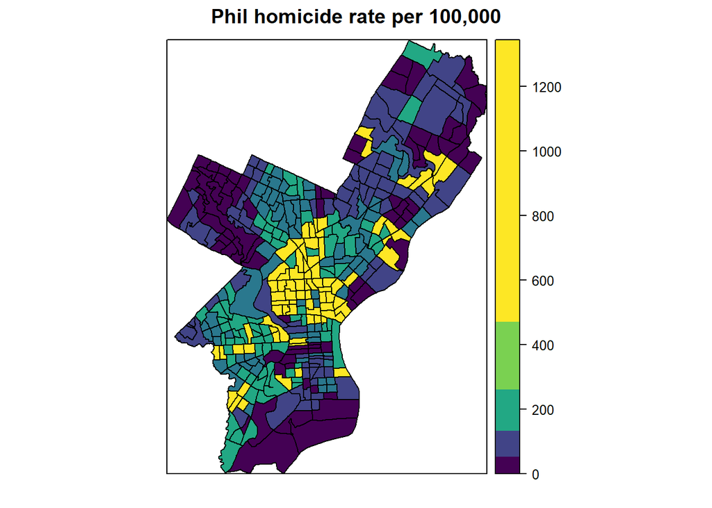

```r
spplot(philly, "HOMIC_R", col.regions=viridis(length(br)), at = br,
       main = "Phil homicide rate per 100,000")
```

##### **(c)** Comment upon the good/bad of using *quantiles* to choose the breakpoint for discretization.

- **Quantiles classification carries same kind of features.Therefore, Linearly distributed responds well to quantile classsification.**
- **Quantiles classification can result in misleading, unreadable outputs. We can group features into groups with distinct type of values**

Tweeking a little further, the biggest remainig issue is the legend, which shows as a graduated scale even though we have discretized the coloring. Here is how we can change this:

```
- Use the `cut()` function from the base package with the values from `philly$HOMIC_R` and the corrected breaks `br` to return a vector with the respective boundaries of the brackets. Use `?cut` if you need help.
- Assign the output vector you get as a new column `HOMIC_R_bracket` to the `philly` attributes table. It will help to map the color based on the breaks. Take a look at the values. What object class is that vector?
- Remove the `at=` parameter in `spplot()` (which is only needed for continuous variables) and tell it to plot `HOMIC_R_bracket`.
```

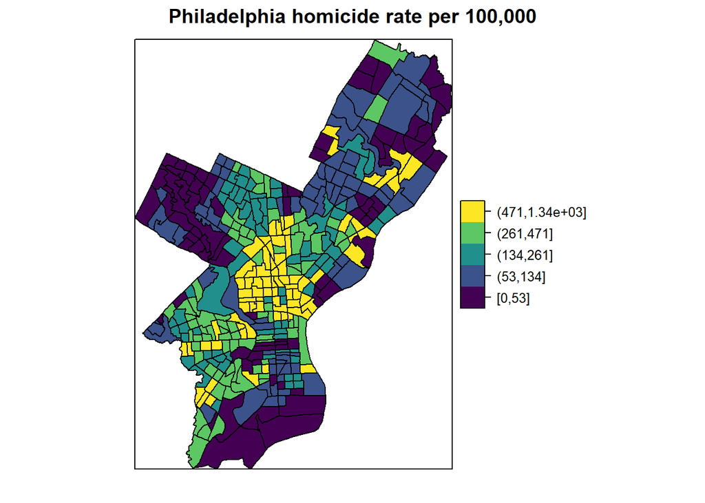

```r
philly$HOMIC_R_bracket <- cut(philly$HOMIC_R, br,include.lowest = T)
spplot(philly, "HOMIC_R_bracket", col.regions=viridis(5), main = "Philadelphia homicide rate per 100,000")
```

There are many more arguments for this function to provide additional plot parameters, like the legend position, labels, scales, etc.

However, as you have seen, this can be quite tedious.

As an alternative you may want to be aware of the [`GISTools`](https://CRAN.R-project.org/package=GISTools) package. It includes functions, like `choropleth()` to draw choropleth that are really just convenience functions that wrap around `spplot()`

## 3. Plotting simple features (`sf`) with `plot`

The `sf` package looks to connect R more closely with GIS industry standards and looks to be the follow-on to the `sp` package. For a longer description, you can read https://cran.r-project.org/web/packages/sf/vignettes/sf1.html .

The `sf` package extends the base `plot` command, so it can be used on `sf` objects. If used without any arguments it will plot all the attributes, like `spplot` does.

To work in the *sf* package, we need an *sf object*. We could do a conversion, (from the sp object we have been using), but I want to emphasize reproducibility.

Let’s go back, read from a file. The reader command reads directly from the “shape” file, which is inside the Philly directory.

```r
philly_sf <-  st_read("Philly3/Philly3.shp")
```

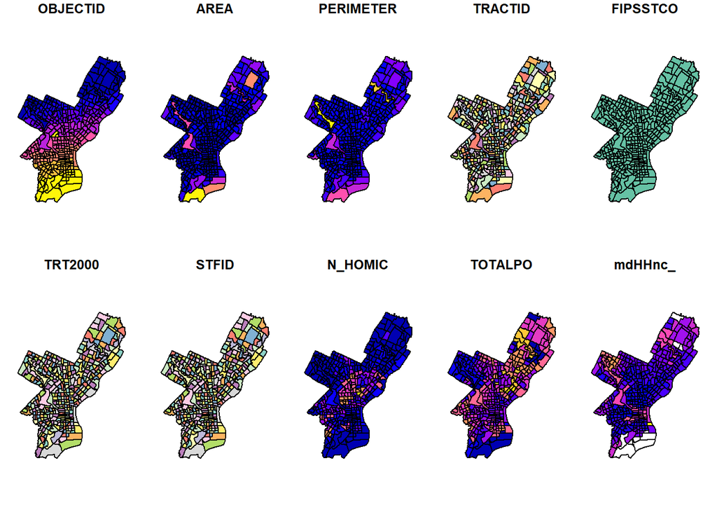

```r
plot(philly_sf)
```

Take a look at the structure of `philly_sf`. You’ll observe a more compact (simple) structure than from `philly`, where now the geometry is just one of the attributes.

To plot a fewer attributes we need to provide an object of class `sf`, which has been subsetted appropriately. I am going to accomplish by using one of my *dplyr* tools (the `select()` function) using *chaining*:

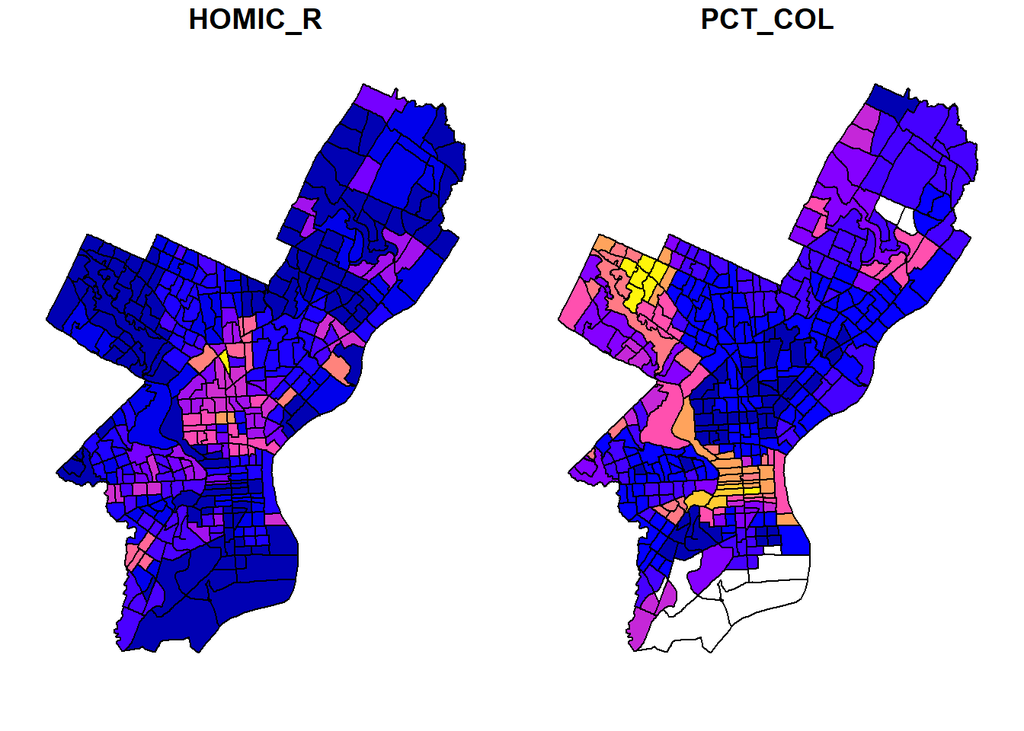

```r
sf2= philly_sf %>% select(HOMIC_R,PCT_COL)
plot(sf2)
```

##### **(a)** Create your own plot of this sf object using the plot command, but where you plot 3 variables of your choosing.

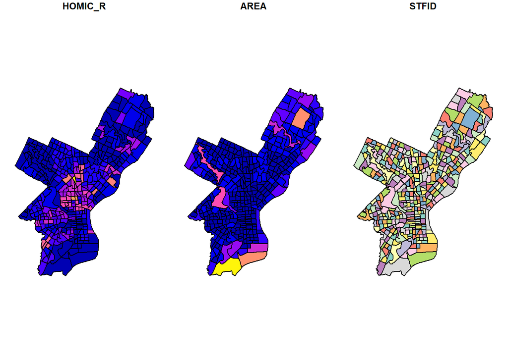

```r
sf3= philly_sf %>% select(HOMIC_R,AREA,STFID)
plot(sf3)
```

> `sf` is an important package for data manipulation and integration with other programs (hence - conformance to formal ISO standards), it is probably not the most friendly tool for analytic visualization. So … we move on.

## 4. Choropleth mapping with `ggplot2`

[`ggplot2`](http://ggplot2.org/) is a widely used and powerful plotting library for R. It is not specifically geared towards mapping, but one can generate great maps.

As we already have some reasonable experience with ggplot2, let me simply explain this way: we have made plots in ggplot2 using `geom_bar`, and `geom_line`, and …. We are now simply going to use a new *geometry*.

If you read my “source” for this lesson (dtd May, 2017), you will see a significant explanation on how to use ggplot2 for mapping. However, that approach is no longer required.

R continually evolves. The advent of the `sf` package, which follows a `tidy` structuring of the sf objects allowed for an easy inclusion into the ggplot2 world. A new geometry, `geom_sf` is available in the development branch of ggplot2.

You can install that version of ggplot2, and then the code below (using ggplot2) will work: To install

```
# Or the the development version from GitHub:
# install.packages("devtools")
devtools::install_github("tidyverse/ggplot2")
```

Here you see our Philly map, where I have used standard “ggplot” terminology, to include plotting with transparency.

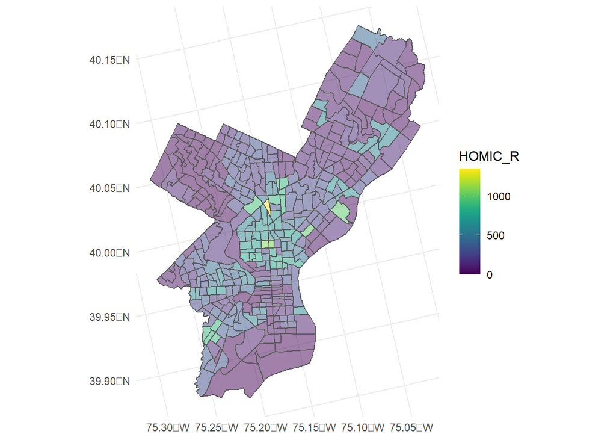

```r
ggplot(philly_sf) +
  geom_sf(aes(fill=HOMIC_R),alpha=.5) +
  scale_fill_viridis()+
  theme_minimal()
```

##### **(a)** Using ggplot2, create your own chloropleth plot using the Philadephia, but plotting a different variable from the dataset.

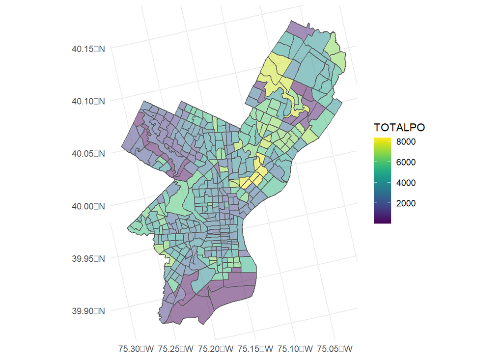

```r
ggplot(philly_sf) +
  geom_sf(aes(fill=TOTALPO),alpha=.5) +
  scale_fill_viridis()+
  theme_minimal()
```

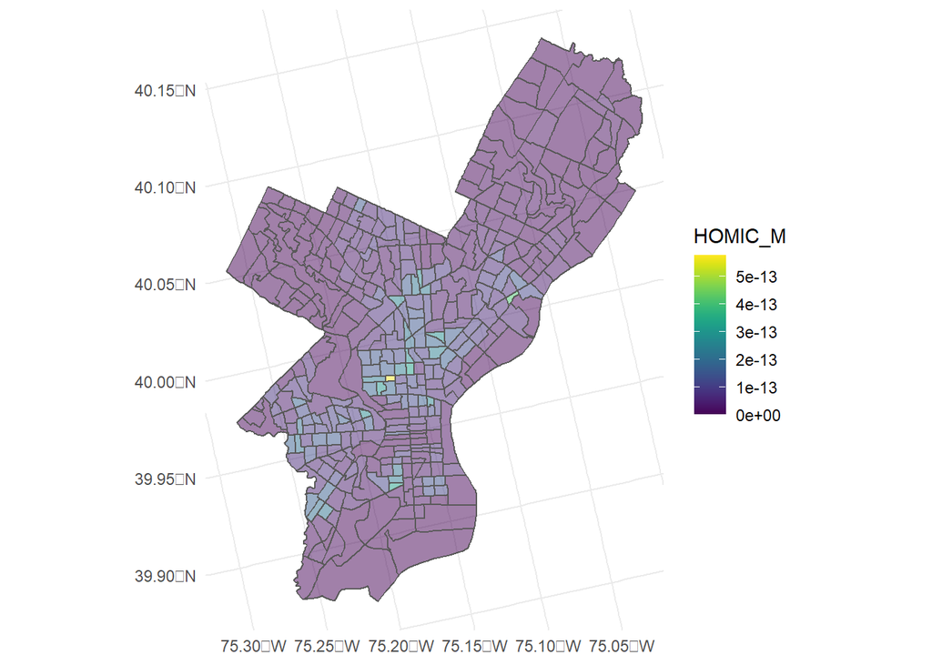

```r
philly_sf$HOMIC_M<-philly_sf$N_HOMIC/philly_sf$AREA*3.59E-8
ggplot(philly_sf) +
  geom_sf(aes(fill=HOMIC_M),alpha=.5) +
  scale_fill_viridis()+
  theme_minimal()
```

# STOP HERE

The material below requires you to register for a Google API key, which I am not asking you to do.

## 5. Basemaps with ggmap

`ggmap` builds on `ggplot` and allows to pull in tiled basemaps from different services, like Google Maps and OpenStreetMaps[^6].

In addition to providing a “base layer” for visualizations, ggmap also supports measuring and routing functionality, with routing as accessed via interfacing with the google routing api.

However, since our primary focus is visualization, (as opposed to analysis) lets focus on the visualization piece.

As key concept, ggmap allows you to put a map background at the foundation of a ggplot. Then, you can add essesntially any type of layers to that plot using ggplot2 geometries, labels, etc.

So let’s overlay the map from above on a google satellite basemap.

#### Exercise 3

First we use the `get_map()` command from `ggmap` to pull down the basemap. We need to tell it the location or the boundaries of the map, the zoom level, and what kind of map service we like (default is Google terrain). It will actually download the tile. `get_map()` returns a ggmap object, name it `ph_basemap`.

```
In order to view the map we then use `ggmap(ph_basemap)`.

Look up the syntax of `?get_map()`, go back and forth between `get_map(..)` and `ggmap(ph_basemap)` to find the correct parameters for our example.
```

```r
#ph_basemap <- get_map(location="Philadelphia, PA", zoom=11, maptype = 'terrain',source="stamen")
#ggmap(ph_basemap)
```

Then we can reuse the code from the ggplot example above, replacing the first line, where we initialized a ggplot object above

```
    ggplot() +
    ...

with the line to call our basemap:

    ggmap(ph_basemap) +
    ...


See if you can copy and paste this together.
```

```r
# ph_3857 <- st_transform(philly_sf, 3857)
#
# ggmap_bbox <- function(map) {
#   if (!inherits(map, "ggmap")) stop("map must be a ggmap object")
#   # Extract the bounding box (in lat/lon) from the ggmap to a numeric vector,
#   # and set the names to what sf::st_bbox expects:
#   map_bbox <- setNames(unlist(attr(map, "bb")),
#                        c("ymin", "xmin", "ymax", "xmax"))
#
#   # Coonvert the bbox to an sf polygon, transform it to 3857,
#   # and convert back to a bbox (convoluted, but it works)
#   bbox_3857 <- st_bbox(st_transform(st_as_sfc(st_bbox(map_bbox, crs = 4326)), 3857))
#
#   # Overwrite the bbox of the ggmap object with the transformed coordinates
#   attr(map, "bb")$ll.lat <- bbox_3857["ymin"]
#   attr(map, "bb")$ll.lon <- bbox_3857["xmin"]
#   attr(map, "bb")$ur.lat <- bbox_3857["ymax"]
#   attr(map, "bb")$ur.lon <- bbox_3857["xmax"]
#   map
# }
#
# ph_basemap <- ggmap_bbox(ph_basemap)
#
#
# ggmap(ph_basemap)+
#   coord_sf(crs = st_crs(3857)) +
#   geom_sf(data=ph_3857,inherit.aes=FALSE,
#           aes(fill=HOMIC_R)) +
#     scale_fill_viridis()
```

# More on this lesson will appear later this week.

[^1]: For the correction of breaks after using classIntervals with spplot/levelplot see here http://r.789695.n4.nabble.com/SpatialPolygon-with-the-max-value-gets-no-color-assigned-in-spplot-function-when-using-quot-at-quot-r-td4654672.html